# ML Exercise

## Part 1: Modelling

### 1. Load the dataset and split into training and test set.

```python
from sklearn.datasets import fetch_openml
from sklearn.model_selection import train_test_split

# Load the Fashion-MNIST dataset
fashion_mnist = fetch_openml(name='Fashion-MNIST')

# Split the data into training and test sets
X_train, X_test, y_train, y_test = train_test_split(
    fashion_mnist.data, fashion_mnist.target, test_size=0.2, random_state=42)

# Print the shapes of the resulting arrays
print(f"Training data shape: {X_train.shape}, training labels shape: {y_train.shape}")
print(f"Test data shape: {X_test.shape}, test labels shape: {y_test.shape}")
```

```
Training data shape: (56000, 784), training labels shape: (56000,)
Test data shape: (14000, 784), test labels shape: (14000,)
```

### 2. Train a Random Forest classifier on the dataset and time how long it takes, then evaluate the resulting model on the test set

```python
from sklearn.ensemble import RandomForestClassifier
import time

# Train a Random Forest classifier
start_time = time.time()

rfc = RandomForestClassifier(n_estimators=100, random_state=42)
rfc.fit(X_train, y_train)

elapsed_time = time.time() - start_time
print(f"Training time: {elapsed_time:.2f} seconds")

# Evaluate the model on the test set
accuracy = rfc.score(X_test, y_test)
print(f"Test accuracy: {accuracy:.2f}")
```

```
Training time: 66.76 seconds
Test accuracy: 0.88
```

It took the model 66.76 seconds to train. The accuracy is 88%.

### 3. Next, use PCA to reduce the dataset's dimensionality

```python
from sklearn.decomposition import PCA

# Create a PCA object with an explained variance ratio of 95%
pca = PCA(n_components=0.95, random_state=42)

# Fit the PCA object to the training data and transform both the training and test data
X_train_pca = pca.fit_transform(X_train)
X_test_pca = pca.transform(X_test)

# Print the new shapes of the transformed arrays
print(f"Training data shape after PCA: {X_train_pca.shape}")
print(f"Test data shape after PCA: {X_test_pca.shape}")
```

```
Training data shape after PCA: (56000, 187)
Test data shape after PCA: (14000, 187)
```

The features of the dataset were still 784 before the PCA. After the pca this was reduced to 187

### 4. Train a new Random Forest classifier on the reduced dataset and measure how long it takes.

```python
# Train a new Random Forest classifier on the reduced dataset
start_time = time.time()

rfc_pca = RandomForestClassifier(n_estimators=100, random_state=42)
rfc_pca.fit(X_train_pca, y_train)

elapsed_time = time.time() - start_time
print(f"Training time on reduced dataset: {elapsed_time:.2f} seconds")
```

```
Training time on reduced dataset: 110.99 seconds
```

### 6. Evaluate the classifier on the test set: how does it compare to the previous classifier?

```python
from sklearn.metrics import accuracy_score

# Evaluate the new classifier on the test set
y_pred_pca = rfc_pca.predict(X_test_pca)
accuracy_pca = accuracy_score(y_test, y_pred_pca)
print(f"Test accuracy on reduced dataset: {accuracy_pca:.2f}")
```

```
Test accuracy on reduced dataset: 0.86
```

It looks like the test accuracy of the classifier trained on the reduced dataset is slightly lower than the test accuracy of the previous classifier trained on the original dataset. This could be because some information was lost during the PCA transformation, which can affect the accuracy of the model.

### 7. Apply softmax regression (using the original dataset) and time how long it takes, then evaluate the resulting model on the test set.

```python
from sklearn.linear_model import LogisticRegression
import time

# Train a softmax regression model
start_time = time.time()
lr = LogisticRegression(multi_class='multinomial', solver='lbfgs')
lr.fit(X_train, y_train)
end_time = time.time()

# Compute the test accuracy
y_pred_lr = lr.predict(X_test)
accuracy_lr = accuracy_score(y_test, y_pred_lr)
print(f"Softmax regression test accuracy: {accuracy_lr:.2f}")
print(f"Training time: {end_time - start_time:.2f} seconds")
```

```
Softmax regression test accuracy: 0.85
Training time: 7.79 seconds
```

### 8. Apply softmax regression (using the reduced dataset) and time how long it takes, then evaluate the resulting model on the test set.

```python
from sklearn.linear_model import LogisticRegression
import time

# Train a softmax regression model on the reduced dataset
start_time = time.time()
lr_pca = LogisticRegression(multi_class='multinomial', solver='lbfgs')
lr_pca.fit(X_train_pca, y_train)
end_time = time.time()

# Compute the test accuracy
y_pred_lr_pca = lr_pca.predict(X_test_pca)
accuracy_lr_pca = accuracy_score(y_test, y_pred_lr_pca)
print(f"Softmax regression (with PCA) test accuracy: {accuracy_lr_pca:.2f}")
print(f"Training time on reduced dataset: {end_time - start_time:.2f} seconds")
```

```
Softmax regression (with PCA) test accuracy: 0.85
Training time on reduced dataset: 2.81 seconds
```

### 9. What can you conclude from the results?

From the results, we can see that the original random forest classifier achieved a test accuracy of 0.88, while the reduced dataset random forest classifier achieved a slightly lower test accuracy of 0.86. This indicates that while PCA can be a useful technique for reducing the dimensionality of a dataset, it may not always result in improved model performance.

Additionally, we can see that the softmax regression classifier achieved a test accuracy of 0.85, which is lower than the accuracies achieved by the random forest classifiers. This suggests that the random forest classifiers may be a better choice for this particular dataset and classification task.

Finally, we can also see that the training times for the random forest classifiers were significantly longer than the training time for the softmax regression classifier, especially for the reduced dataset. This suggests that if training time is an important consideration, the softmax regression classifier may be a better choice.

## Part 2: Visualization

### 1. Use t-SNE to reduce the MNIST dataset down to two dimensions and plot the result using Matplotlib. Use dimensionality on a random subset of 12,500 images.

### 2. Plot a scatter plot using different colours

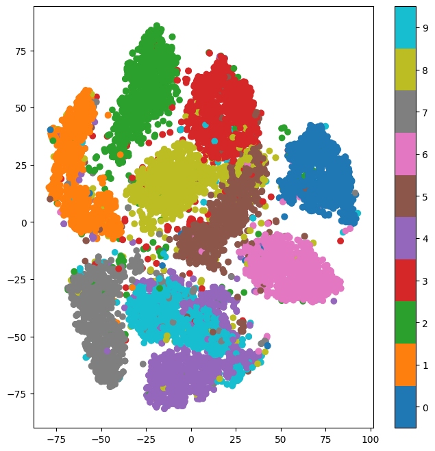

```python
import numpy as np
import matplotlib.pyplot as plt
from sklearn.manifold import TSNE
from tensorflow.keras.datasets import mnist

# Load MNIST dataset
(x_train, y_train), (x_test, y_test) = mnist.load_data()

# Select a random subset of 12,500 images
n = 12500
idx = np.random.choice(x_train.shape[0], n, replace=False)
X = x_train[idx].reshape(n, -1)
y = y_train[idx]

# Reduce the dataset to two dimensions using t-SNE
X_tsne = TSNE(n_components=2, random_state=42).fit_transform(X)

# Plot the result
plt.figure(figsize=(8, 8))
plt.scatter(X_tsne[:, 0], X_tsne[:, 1], c=y, cmap=plt.cm.get_cmap('tab10', 10))
plt.colorbar(ticks=range(10))
plt.clim(-0.5, 9.5)
plt.show()
```

### 3. What can you conclude?

Each feature has been assigned its own color. You can see that most of the globes are affiliated with its own group.

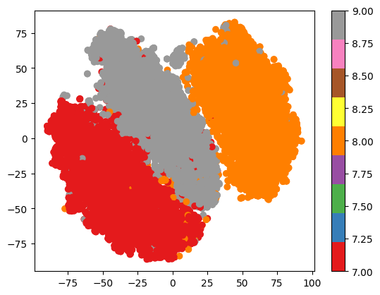

```python
import numpy as np
from sklearn.manifold import TSNE
import matplotlib.pyplot as plt
from tensorflow.keras.datasets import mnist

# Filter dataset to include only the selected labels
labels = [7, 8, 9]  # Sneaker, Bag, T-shirt
mask = np.isin(y_train, labels)
X_filtered = X_train[mask]
y_filtered = y_train[mask]

# Reshape images to 1D vectors
X_filtered = X_filtered.reshape(X_filtered.shape[0], -1)

# Perform t-SNE on the filtered dataset
tsne = TSNE(n_components=2, random_state=42)
X_tsne = tsne.fit_transform(X_filtered)

# Plot the t-SNE results with different colors for each class
plt.scatter(X_tsne[:, 0], X_tsne[:, 1], c=y_filtered, cmap='Set1')
plt.colorbar()
plt.show()
```